# DA 101 Week 7-8

Prof Miller

12 April, 2020

## The Data

Recall the `iris` dataset with measurements about 150 iris flowers:

```r
iris
```

| Sepal.Length | Sepal.Width | Petal.Length | Petal.Width | Species |
| --- | --- | --- | --- | --- |
| 5.1 | 3.5 | 1.4 | 0.2 | setosa |
| 4.9 | 3.0 | 1.4 | 0.2 | setosa |
| 4.7 | 3.2 | 1.3 | 0.2 | setosa |
| 4.6 | 3.1 | 1.5 | 0.2 | setosa |
| 5.0 | 3.6 | 1.4 | 0.2 | setosa |
| 5.4 | 3.9 | 1.7 | 0.4 | setosa |
| 4.6 | 3.4 | 1.4 | 0.3 | setosa |
| 5.0 | 3.4 | 1.5 | 0.2 | setosa |
| 4.4 | 2.9 | 1.4 | 0.2 | setosa |
| 4.9 | 3.1 | 1.5 | 0.1 | setosa |

[output cut: 140 more lines]

## First Model: Predicting With a Categorical Variable

Here’s a model predicting `Sepal.Length` based only upon a single categorical variable: `Species`. What does the model do? Simple: it predicts the mean for each species! Take a look at the model coefficients:

```r
speciesMod <- lm(data=iris,
                 Sepal.Length~Species)

pander(summary(speciesMod))
```

|  | Estimate | Std. Error | t value | Pr(>\|t\|) |
| --- | --- | --- | --- | --- |
| **(Intercept)** | 5.006 | 0.0728 | 68.76 | 1.134e-113 |
| **Speciesversicolor** | 0.93 | 0.103 | 9.033 | 8.77e-16 |
| **Speciesvirginica** | 1.582 | 0.103 | 15.37 | 2.215e-32 |

Fitting linear model: Sepal.Length ~ Species

| Observations | Residual Std. Error | $R^2$ | Adjusted $R^2$ |
| --- | --- | --- | --- |
| 150 | 0.5148 | 0.6187 | 0.6135 |

Note a seeming deficiency in the model: only *versicolor* and *virginica* have coefficients. What happened to *setosa*?

In our “dummy variable” model, one level of the category is absorbed into the intercept as a baseline (here, *setosa* is our baseline, chosen only by alphabetical order). Other levels (in this case *versicolor* and *virginica*) are expressed in binary (which is to say either $x =$ 0 or $x =$ 1) relative to the baseline.

All together, the model:

$$\hat{y}=5.006+0.930 x_1 + 1.582 x_2$$
Here, $x_1$ is a binary “dummy variable” that indicates versicolor irises and $x_2$ is a binary variable that indicates virginica plants.

Those are the coefficients of the model, but what does it look like?

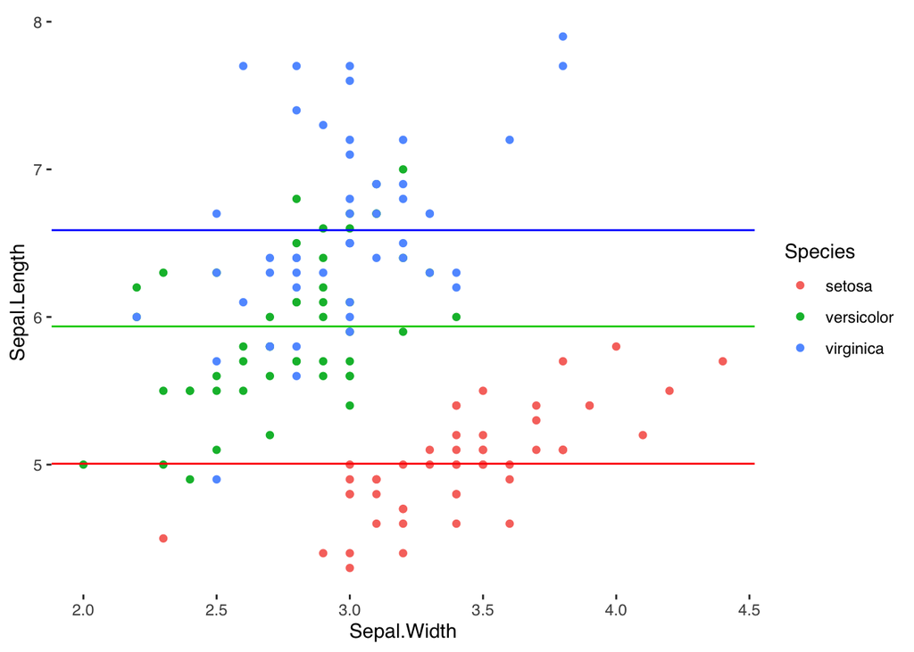

```r
iris %>% ggplot(aes(Sepal.Width, Sepal.Length, color=Species))+
  geom_point()+
  geom_abline(intercept = c(5.0060, 5.0060+.9300, 5.0060+1.5820),
              slope=0, color=c("red", "green3", "blue"))
```

The picture is clear: regressing on a categorical variable simply predicts the mean for each category!

## Regressing on Two Variables: Categorical and Quantitative

```r
speciesAndSepalWidthMod <- lm(data=iris,
                              Sepal.Length~Sepal.Width+Species)

summary(speciesAndSepalWidthMod) %>% pander(justify="center")
```

|  | Estimate | Std. Error | t value | Pr(>\|t\|) |
| --- | --- | --- | --- | --- |
| **(Intercept)** | 2.251 | 0.3698 | 6.089 | 9.568e-09 |
| **Sepal.Width** | 0.8036 | 0.1063 | 7.557 | 4.187e-12 |
| **Speciesversicolor** | 1.459 | 0.1121 | 13.01 | 3.478e-26 |
| **Speciesvirginica** | 1.947 | 0.1 | 19.47 | 2.094e-42 |

Fitting linear model: Sepal.Length ~ Sepal.Width + Species

| Observations | Residual Std. Error | $R^2$ | Adjusted $R^2$ |
| --- | --- | --- | --- |
| 150 | 0.438 | 0.7259 | 0.7203 |

Observe that `Sepal.Width` is a numerical variable, and its coefficient is a slope. All other coefficients merely affect the intercept. Take a look:

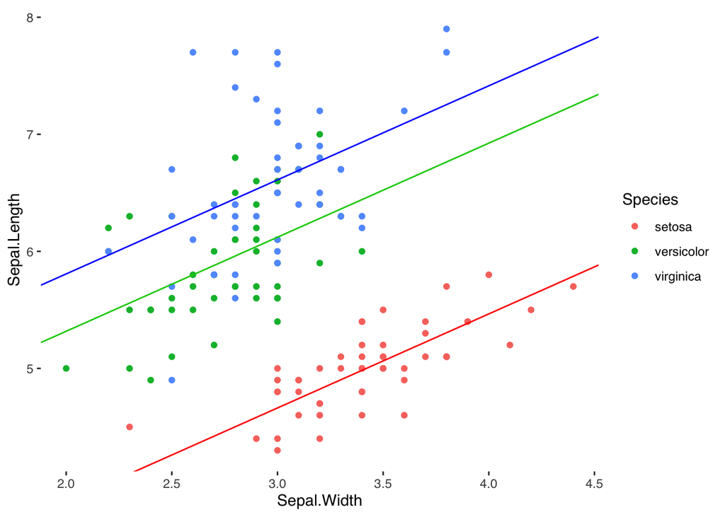

```r
qplot(data=iris,
      x=Sepal.Width, y=Sepal.Length,
      color=Species)+
  geom_abline(intercept = c(2.2514,2.2514+1.4587,2.2514+1.9486),
              slope=.8036, color=c("red", "green3", "blue"))
```

## Using Multiple Variables

Just for fun, we consider a model for `Sepal.Length` using every other variable in the `iris` data frame.

```r
finalModel <- lm(data=iris, Sepal.Length~.)
summary(finalModel) %>% pander
```

|  | Estimate | Std. Error | t value | Pr(>\|t\|) |
| --- | --- | --- | --- | --- |
| **(Intercept)** | 2.171 | 0.2798 | 7.76 | 1.43e-12 |
| **Sepal.Width** | 0.4959 | 0.08607 | 5.761 | 4.868e-08 |
| **Petal.Length** | 0.8292 | 0.06853 | 12.1 | 1.074e-23 |
| **Petal.Width** | -0.3152 | 0.1512 | -2.084 | 0.03889 |
| **Speciesversicolor** | -0.7236 | 0.2402 | -3.013 | 0.00306 |
| **Speciesvirginica** | -1.023 | 0.3337 | -3.067 | 0.002584 |

Fitting linear model: Sepal.Length ~ .

| Observations | Residual Std. Error | $R^2$ | Adjusted $R^2$ |
| --- | --- | --- | --- |
| 150 | 0.3068 | 0.8673 | 0.8627 |

Here, our model is

$$\hat{y} = 2.171 - 0.7236x_1 -1.023x_2+0.4959x_3+0.8292x_4-0.3152x_5$$
where $x_1$ and $x_2$ are dummy variables for *versicolor* and *virginica*, and $x_3$, $x_4$, and $x_5$ are the quantitative measurements for `Sepal.Width`, `Petal.Length`, and `Petal.Width`.

Since a four-dimensional visualization of the model is inconvenient, we defer to a diagnostic plot:

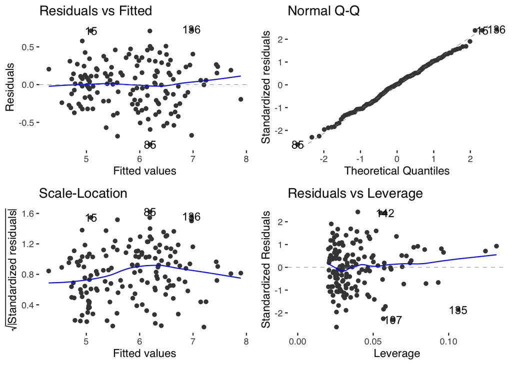

```r
autoplot(finalModel)
```

Observe that our residuals don’t exhibit any “bad behavior”, in particular:

- No polynomial pattern is detected in the residual plot at upper left
- Residuals seem fairly homoskedastic per the scale-location plot at lower left
- Normality of residuals is observed at upper right
- The high-leverage observations tend to have small residuals, as seen at lower right.